# Practical Machine Learning Project

Angelika

December 11, 2019

## Problem Description (from Instructor)

Using devices such as Jawbone Up, Nike FuelBand, and Fitbit it is now possible to collect a large amount of data about personal activity relatively inexpensively. These types of devices are part of the quantified self-movement - a group of enthusiasts who take measurements about themselves regularly to improve their health, to find patterns in their behavior, or because they are tech geeks. One thing that people regularly do is quantify how much of a particular activity they do, but they rarely quantify how well they do it. In this project, the goal is to use data from accelerometers on the belt, forearm, arm, and dumbbell of 6 participants. They were asked to perform barbell lifts correctly and incorrectly in 5 different ways. More information is available from the website here: http://groupware.les.inf.puc-rio.br/har (see the section on the Weight Lifting Exercise Dataset).

The goal of your project is to predict the manner in which they did the exercise. This is the “classe” variable in the training set.

## Loading the data

The code below creates a “coursera_practical_machine_learning” directory within user’s current working directory, downloads both the train and test datafiles directly from the source, and reads them in using the data.table package. The first few entries of the dataset are presented in the output below.

```r
library("data.table")

if (!file.exists("coursera_practical_machine_learning")){dir.create("coursera_practical_machine_learning")}
fileUrl <- "https://d396qusza40orc.cloudfront.net/predmachlearn/pml-training.csv"
download.file(fileUrl, destfile = "./coursera_practical_machine_learning/pml-training.csv", method = "curl")

train<-read.csv("./coursera_practical_machine_learning/pml-training.csv", header=TRUE)

fileUrl <- "https://d396qusza40orc.cloudfront.net/predmachlearn/pml-testing.csv"
download.file(fileUrl, destfile = "./coursera_practical_machine_learning/pml-testing.csv", method = "curl")

test<-read.csv("./coursera_practical_machine_learning/pml-testing.csv", header=TRUE)

head(train)
```

```
##   X user_name raw_timestamp_part_1 raw_timestamp_part_2   cvtd_timestamp
## 1 1  carlitos           1323084231               788290 05/12/2011 11:23
## 2 2  carlitos           1323084231               808298 05/12/2011 11:23
## 3 3  carlitos           1323084231               820366 05/12/2011 11:23
## 4 4  carlitos           1323084232               120339 05/12/2011 11:23
## 5 5  carlitos           1323084232               196328 05/12/2011 11:23
## 6 6  carlitos           1323084232               304277 05/12/2011 11:23
##   new_window num_window roll_belt pitch_belt yaw_belt total_accel_belt
## 1         no         11      1.41       8.07    -94.4                3
## 2         no         11      1.41       8.07    -94.4                3
## 3         no         11      1.42       8.07    -94.4                3
## 4         no         12      1.48       8.05    -94.4                3
## 5         no         12      1.48       8.07    -94.4                3
## 6         no         12      1.45       8.06    -94.4                3
##   kurtosis_roll_belt kurtosis_picth_belt kurtosis_yaw_belt
```

[output cut: 265 more lines]

## Date Cleaning and Pre-Processing

There appear to be some columns that have a lot of null values, perhaps even the entire column is null. We remove such columns for both the test and train datasets.

```r
library(dplyr)
dim(train)
```

```
## [1] 19622   160
```

```r
not_any_na <- function(x) all(!is.na(x))
train<-train %>% select_if(not_any_na)
test<-test %>% select_if(not_any_na)
head(train)
```

```
##   X user_name raw_timestamp_part_1 raw_timestamp_part_2   cvtd_timestamp
## 1 1  carlitos           1323084231               788290 05/12/2011 11:23
## 2 2  carlitos           1323084231               808298 05/12/2011 11:23
## 3 3  carlitos           1323084231               820366 05/12/2011 11:23
## 4 4  carlitos           1323084232               120339 05/12/2011 11:23
## 5 5  carlitos           1323084232               196328 05/12/2011 11:23
## 6 6  carlitos           1323084232               304277 05/12/2011 11:23
##   new_window num_window roll_belt pitch_belt yaw_belt total_accel_belt
## 1         no         11      1.41       8.07    -94.4                3
## 2         no         11      1.41       8.07    -94.4                3
## 3         no         11      1.42       8.07    -94.4                3
## 4         no         12      1.48       8.05    -94.4                3
## 5         no         12      1.48       8.07    -94.4                3
## 6         no         12      1.45       8.06    -94.4                3
##   kurtosis_roll_belt kurtosis_picth_belt kurtosis_yaw_belt
## 1
## 2
## 3
## 4
## 5
## 6
##   skewness_roll_belt skewness_roll_belt.1 skewness_yaw_belt max_yaw_belt
## 1
## 2
## 3
## 4
## 5
## 6
##   min_yaw_belt amplitude_yaw_belt gyros_belt_x gyros_belt_y gyros_belt_z
## 1                                         0.00         0.00        -0.02
## 2                                         0.02         0.00        -0.02
## 3                                         0.00         0.00        -0.02
## 4                                         0.02         0.00        -0.03
## 5                                         0.02         0.02        -0.02
## 6                                         0.02         0.00        -0.02
##   accel_belt_x accel_belt_y accel_belt_z magnet_belt_x magnet_belt_y
## 1          -21            4           22            -3           599
## 2          -22            4           22            -7           608
## 3          -20            5           23            -2           600
## 4          -22            3           21            -6           604
```

[output cut: 106 more lines]

```
## 6                  36            0.02           -0.02           -0.03
##   accel_forearm_x accel_forearm_y accel_forearm_z magnet_forearm_x
## 1             192             203            -215              -17
## 2             192             203            -216              -18
## 3             196             204            -213              -18
## 4             189             206            -214              -16
## 5             189             206            -214              -17
## 6             193             203            -215               -9
##   magnet_forearm_y magnet_forearm_z classe
## 1              654              476      A
## 2              661              473      A
## 3              658              469      A
## 4              658              469      A
## 5              655              473      A
## 6              660              478      A
```

We started out with 160 variables and now have 93. Additionally, the first few columns do not contain information regarding how well an activity is performed and mostly serve the role of primary keys for these data. For the purposes of the analysis, they can be ignored and, hence, removed from the dataset.

```r
train<- train[,-c(1:7)]
test<- test[,-c(1:7)]
dim(train)
```

```
## [1] 19622    86
```

```r
dim(test)
```

```
## [1] 20 53
```

We are not left with 86 variables in the train set and 52 variables in the test set. Since we need to have the same variables in both the training and testing steps, we remove the columns from the train set that are not part of the test set.

```r
names<-names(test)
names<-append(names, "classe")
train<-train[,names(train) %in% names]
dim(train)
```

```
## [1] 19622    53
```

We now have comparable datasets and now we can move onto modeling stage. We note that the train data includes the variable “classe”, which we are attempting to predict.

## Splitting Data into Train and Validate Sets

```r
library(caret)
inTrain = createDataPartition(train$classe, p = 0.70)[[1]]
training= train[ inTrain,]
validation = train[-inTrain,]
```

## Modeling Using Classification Tree

We first fit a classification tree model to these data.

```r
library(rpart)
```

```r
library(rpart.plot)
tree_model<- train(classe~., data=training, method="rpart")
tree_model$finalModel
```

```
## n= 13737
##
## node), split, n, loss, yval, (yprob)
##       * denotes terminal node
##
##  1) root 13737 9831 A (0.28 0.19 0.17 0.16 0.18)
##    2) roll_belt< 130.5 12599 8703 A (0.31 0.21 0.19 0.18 0.11)
##      4) pitch_forearm< -33.95 1083    3 A (1 0.0028 0 0 0) *
##      5) pitch_forearm>=-33.95 11516 8700 A (0.24 0.23 0.21 0.2 0.12)
##       10) roll_forearm< 124.5 7375 4836 A (0.34 0.24 0.15 0.19 0.07)
##         20) magnet_dumbbell_y< 437.5 6068 3590 A (0.41 0.18 0.18 0.17 0.062) *
##         21) magnet_dumbbell_y>=437.5 1307  622 B (0.047 0.52 0.031 0.29 0.11) *
##       11) roll_forearm>=124.5 4141 2875 C (0.067 0.21 0.31 0.2 0.21) *
##    3) roll_belt>=130.5 1138   10 E (0.0088 0 0 0 0.99) *
```

Next, we visualize the tree model via a graphic.

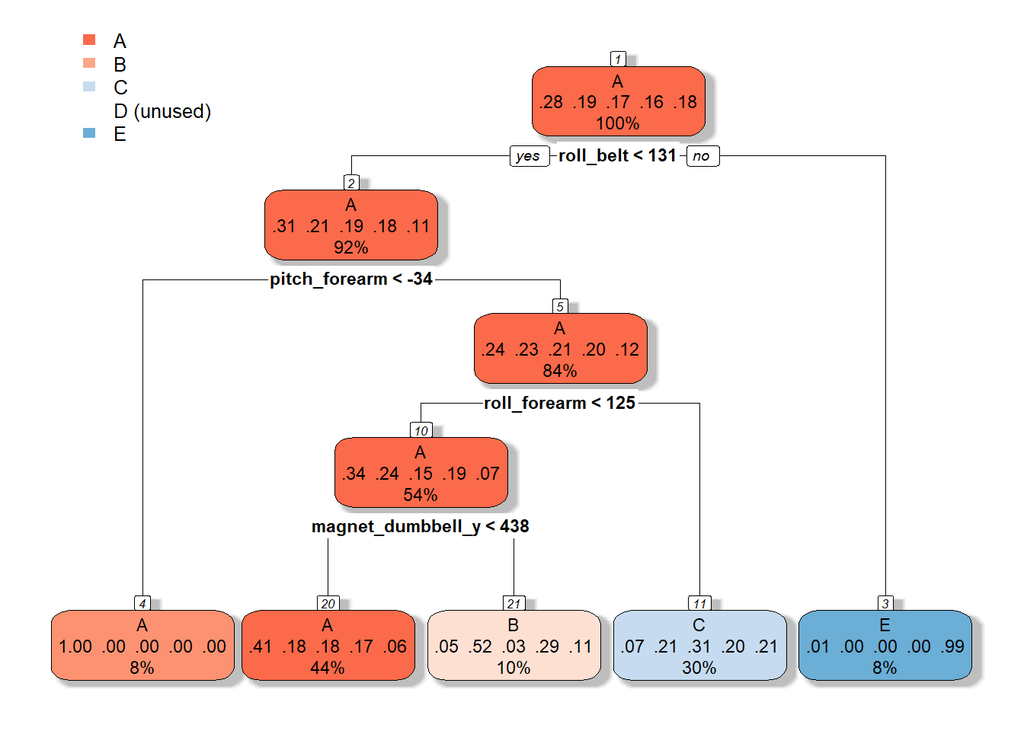

```r
rpart.plot(tree_model$finalModel, box.palette="RdBu", shadow.col="gray", nn=TRUE)
```

Note that rpart automatically performs 10-fold cross-validation when growing a tree. The variables used in the final tree are magnet_dumbbell_y, pitch_forearm, roll_bel, roll_forearm with the relative error of 71 %.

We can estimate the out of sample error by applying the trained model on the validation set.

```r
validate_tree <- predict(tree_model$finalModel, validation, type="class")
confusionMatrix(validation$classe, validate_tree)
```

```
## Confusion Matrix and Statistics
##
##           Reference
## Prediction    A    B    C    D    E
##          A 1520   25  125    0    4
##          B  480  277  382    0    0
##          C  503   13  510    0    0
##          D  425  167  372    0    0
##          E  146   73  360    0  503
##
## Overall Statistics
##
##                Accuracy : 0.4775
##                  95% CI : (0.4647, 0.4903)
##     No Information Rate : 0.5223
##     P-Value [Acc > NIR] : 1
##
##                   Kappa : 0.3174
##
##  Mcnemar's Test P-Value : NA
##
## Statistics by Class:
##
##                      Class: A Class: B Class: C Class: D Class: E
## Sensitivity            0.4945  0.49910  0.29160       NA  0.99211
## Specificity            0.9452  0.83827  0.87524   0.8362  0.89234
## Pos Pred Value         0.9080  0.24320  0.49708       NA  0.46488
## Neg Pred Value         0.6310  0.94142  0.74501       NA  0.99917
## Prevalence             0.5223  0.09431  0.29720   0.0000  0.08615
## Detection Rate         0.2583  0.04707  0.08666   0.0000  0.08547
## Detection Prevalence   0.2845  0.19354  0.17434   0.1638  0.18386
## Balanced Accuracy      0.7198  0.66869  0.58342       NA  0.94222
```

```r
test_tree <- predict(tree_model$finalModel,test, type="class")
test_tree
```

```
##  1  2  3  4  5  6  7  8  9 10 11 12 13 14 15 16 17 18 19 20
##  C  A  C  A  A  C  C  A  A  A  C  C  C  A  C  A  A  A  A  C
## Levels: A B C D E
```

Unfortunately, after submitting these results to the quiz engine, I did not pass the assignment.

## Modeling with Random Forest

So, I try a random forest next because it uses an ensemble of trees so maybe it will work better. First, I train the model

```r
random_forest <- train(classe ~ ., data = train, method = "rf")
print(random_forest)
```

```
## Random Forest
##
## 19622 samples
##    52 predictor
##     5 classes: 'A', 'B', 'C', 'D', 'E'
##
## No pre-processing
## Resampling: Bootstrapped (25 reps)
## Summary of sample sizes: 19622, 19622, 19622, 19622, 19622, 19622, ...
## Resampling results across tuning parameters:
##
##   mtry  Accuracy   Kappa
##    2    0.9930247  0.9911747
##   27    0.9926283  0.9906736
##   52    0.9846718  0.9806069
##
## Accuracy was used to select the optimal model using the largest value.
## The final value used for the model was mtry = 2.
```

```r
validate <- predict(random_forest, validation)
# Show prediction result
confusionMatrix(validation$classe, validate)
```

```
## Confusion Matrix and Statistics
##
##           Reference
## Prediction    A    B    C    D    E
##          A 1674    0    0    0    0
##          B    0 1139    0    0    0
##          C    0    0 1026    0    0
##          D    0    0    0  964    0
##          E    0    0    0    0 1082
##
## Overall Statistics
##
##                Accuracy : 1
##                  95% CI : (0.9994, 1)
##     No Information Rate : 0.2845
##     P-Value [Acc > NIR] : < 2.2e-16
##
##                   Kappa : 1
##
##  Mcnemar's Test P-Value : NA
##
## Statistics by Class:
##
##                      Class: A Class: B Class: C Class: D Class: E
## Sensitivity            1.0000   1.0000   1.0000   1.0000   1.0000
## Specificity            1.0000   1.0000   1.0000   1.0000   1.0000
## Pos Pred Value         1.0000   1.0000   1.0000   1.0000   1.0000
## Neg Pred Value         1.0000   1.0000   1.0000   1.0000   1.0000
## Prevalence             0.2845   0.1935   0.1743   0.1638   0.1839
## Detection Rate         0.2845   0.1935   0.1743   0.1638   0.1839
## Detection Prevalence   0.2845   0.1935   0.1743   0.1638   0.1839
## Balanced Accuracy      1.0000   1.0000   1.0000   1.0000   1.0000
```

Finally, pass the quiz with the following predictions

```r
predict(random_forest, test)
```

```
##  [1] B A B A A E D B A A B C B A E E A B B B
## Levels: A B C D E
```

## References

In preparing this report, I have consulted the following web-sites

https://stackoverflow.com/questions/2643939/remove-columns-from-dataframe-where-all-values-are-na

https://stackoverflow.com/questions/33282174/r-caret-package-error-createdataparition-no-observation

https://blog.exploratory.io/visualizing-a-decision-tree-using-r-packages-in-explortory-b26d4cb5e71f

https://www.gormanalysis.com/blog/decision-trees-in-r-using-rpart/

https://stackoverflow.com/questions/39620287/how-to-create-a-confusion-matrix-for-a-decision-tree-model